# Class 11: Restricted Mean Survival Time Analysis

Xiaoyan Wang

April 1st, 2020

# Outline

- The Hazards of Hazard Ratios
- Solutions for proportional hazard (PH) assumption violation
- Restricted mean survival time (RMST) analysis
- Estimating RMST and between-group differences in R
- Interpreting estimates from RMST analysis

# Cox Proportional Hazard regression

- **Key assumption**: Proportional Hazard
- The hazards in different groups should be proportional
- Hazard ratio remains constant from day 1 of the study until the end of follow-up

# PH assumption

- Depends on the follow-up time
- Reality: Hazards Usually Not Proportional in Medical Studies
- Non-PH may be due to different biological modes of action of the treatments being compared OR to the presence of differentially responsive sub-populations.

# Scenario 1 of PH assumption violation

- No Immediate Effect
- Example: The Air Force/Texas Coronary Atherosclerosis Prevention Study randomly assigned patients with atherosclerotic cardiovascular disease to either statin therapy or placebo (*Stensrud, et al.doi:10.1001/jama.2020.1267; Downs, et al. JAMA. 1998;279(20):1615–1622*)
- Event: adverse cardiovascular events

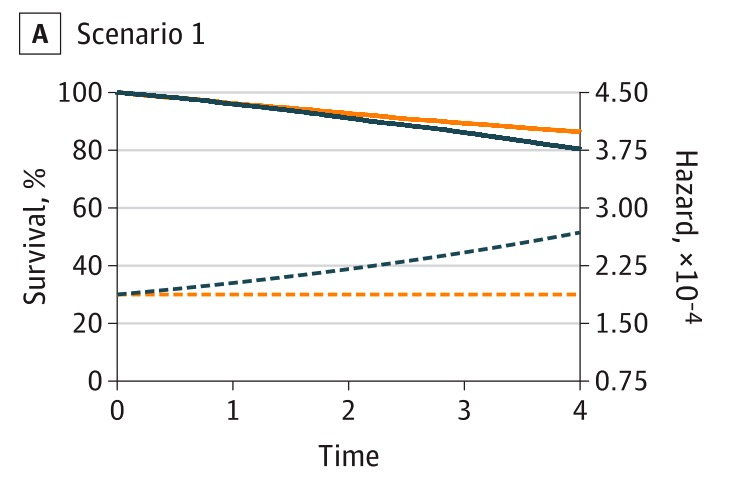

- The effect of statin therapy on cardiovascular events only became evident after 6 months or longer.
- The cumulative incidences of major adverse cardiovascular event in the statin and placebo groups were almost identical during the first 6 months of follow-up
- Both the hazards (dotted lines) and the survival curves (solid lines) gradually diverge after 6 months
- The overall hazard ratio of 0.63 was a weighted average of the time-varying hazard ratios, which were close to 1 in the first months of follow-up and declined later

# Scenario 2 of PH assumption violation

- Immediate and Delayed Effects in Opposite Directions
- Example: The Norwegian Colorectal Cancer Prevention Trial randomly assigned individuals aged 50 to 64 years to flexible sigmoidoscopy screening or no screening (*Holme, et al.JAMA. 1998;279(20):1615–1622*)
- Event: colorectal cancer diagnosis

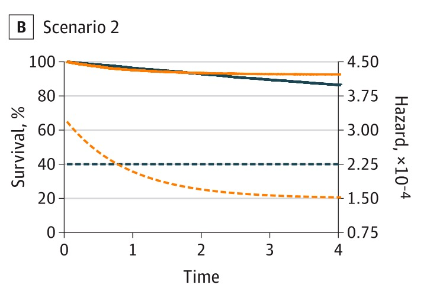

- Screening for colorectal cancer had both an immediate effect on the detection of undiagnosed cancers and a delayed preventive effect due to the removal of cancer precursors
- Both the hazards and the survival curves cross (ie, the hazard ratio goes from greater than 1 to less than 1)
- The hazard ratio of 0.80 was a weighted average of the time-varying hazard ratios, which were greater than 1 in the early follow-up and less than 1 in the later follow-up

# Scenario 3 of PH assumption violation

- Variations in Disease Susceptibility
- A Women’s Health Initiative study randomly assigned postmenopausal women to either estrogen plus progestin hormone therapy or placebo (*Women’s Health Initiative Investigators. JAMA. 2002;288(3):321–333.*)
- Event: coronary heart disease

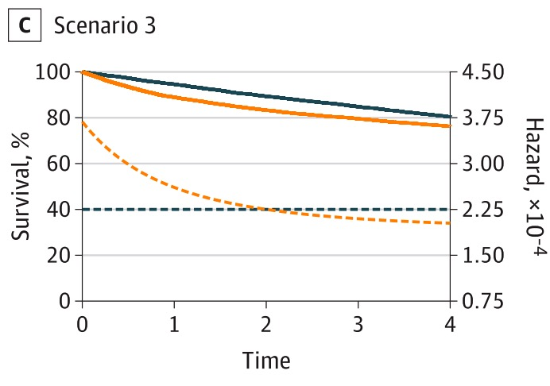

- The hazards cross because of depletion of susceptibles after 2 years in the treatment group, but the survival curves do not cross
- Those with greater disease susceptibility are more likely to experience event earlier and thereby would have been removed more rapidly from the treatment group than from the control group
- Later in the follow-up time, those without the event in the treatment group would have been, on average, less susceptible to developing the disease than those in the control group
- The hazard ratio of event was 1.24 for treatment vs control. However, the hazard ratio was 1.8 during the first year and 0.70 after 5 years of follow-up
- The overall hazard ratio of 1.24 was a weighted average of the time-varying hazard ratios throughout the follow-up

# Pitfalls of hazard ratio (HR)

- When violated, the weighted average hazard ratio is uninterpretable
- Even with no violation, no single summary of a HR can adequately describe the time varying effect
- HR is not clinically meaningful
- HR, as a ratio measure by itself, is difficult to appreciate the magnitude of the treatment effect based on HR without knowing the hazard in control group

# Strengths of the Hazard Ratio

- Widely used
- Effective measure, can be interpreted as incidence rate ratio
- Easily estimated using Cox PH regression

# How to check the PH assumption

- Log-log curves: log(-log(survival)) against log(time)
- Cox.zph function applying Schoenfeld test
- Plot Schoenfeld residuals by time
- Time interaction term

# Checking PH assumption in leukemia data

```r
# Install and load packages
pacman::p_load(tidyverse, survival, survminer, survRM2, haven, gtools, magrittr,
    mlr)

# Read in data Leukemia remission dataset with sex variable found on the internet
leuk <- read_dta("http://web1.sph.emory.edu/dkleinb/allDatasets/surv2datasets/anderson.dta")

# Look at the variables
dput(names(leuk))
```

```
## c("survt", "status", "sex", "logwbc", "rx", "lwbc3")
```

```r
# Cox PH regression
Coxmod <- coxph(Surv(survt, status) ~ sex + logwbc + rx, leuk, ties = "efron")

# Display the model results
summary(Coxmod)
```

```
## Call:
## coxph(formula = Surv(survt, status) ~ sex + logwbc + rx, data = leuk,
##     ties = "efron")
##
##   n= 42, number of events= 30
##
##          coef exp(coef) se(coef)     z Pr(>|z|)
## sex    0.3147    1.3698   0.4545 0.692  0.48872
## logwbc 1.6819    5.3760   0.3366 4.997 5.82e-07 ***
## rx     1.5036    4.4978   0.4615 3.258  0.00112 **
## ---
## Signif. codes:  0 '***' 0.001 '**' 0.01 '*' 0.05 '.' 0.1 ' ' 1
##
##        exp(coef) exp(-coef) lower .95 upper .95
## sex        1.370     0.7300    0.5621     3.338
## logwbc     5.376     0.1860    2.7794    10.398
## rx         4.498     0.2223    1.8204    11.113
##
## Concordance= 0.851  (se = 0.041 )
## Likelihood ratio test= 47.19  on 3 df,   p=3e-10
## Wald test            = 33.54  on 3 df,   p=2e-07
## Score (logrank) test = 48.01  on 3 df,   p=2e-10
```

```r
# Interpretation: After adjusting for covariates, individuals treated with
# placebo have 4.5 (95% CI 1.82-11.11) times higher hazard of replase than
# individuals with treatment.
```

# 1. Log-log curves: log(-log(survival)) against log(time)

```r
# Check PH assumption using log-log survival curves--the curves should be
# parallel
leuksurv <- Surv(leuk$survt, leuk$status)
leuksurv
```

```
##  [1] 35+ 34+ 32+ 32+ 25+ 23  22  20+ 19+ 17+ 16  13  11+ 10+ 10   9+  7   6+  6
## [20]  6   6  23  22  17  15  12  12  11  11   8   8   8   8   5   5   4   4   3
## [39]  2   2   1   1
```

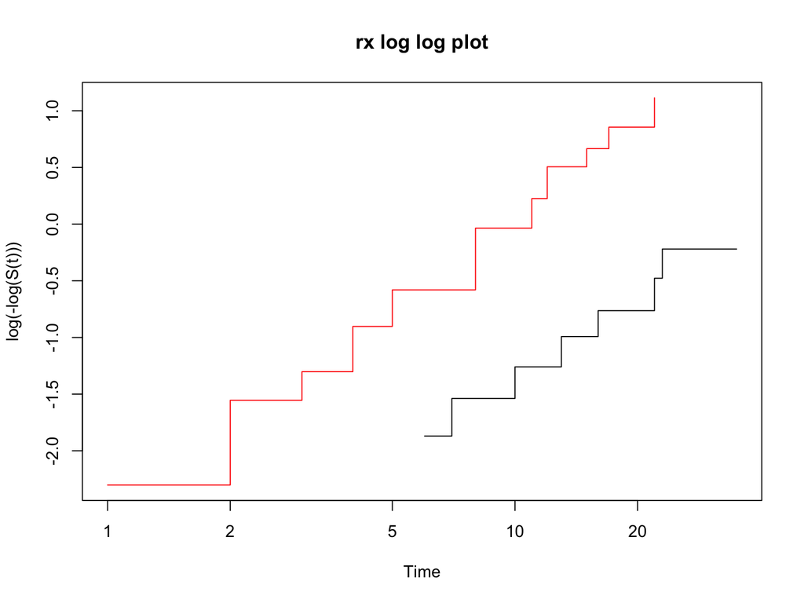

```r
plot(survfit(leuksurv ~ leuk$rx), col = c("black", "red"), main = "rx log log plot",
    fun = "cloglog", xlab = "Time", ylab = "log(-log(S(t)))")  #ph assumption not violated
```

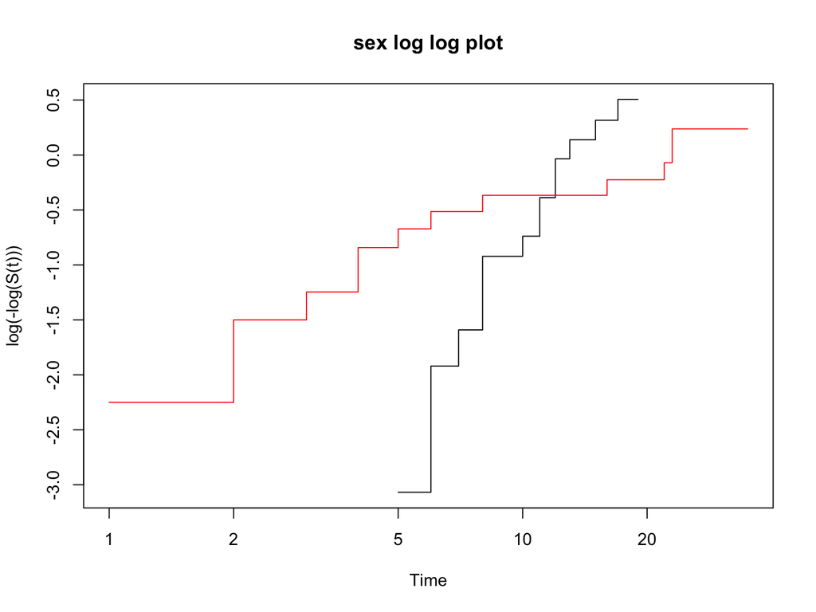

```r
plot(survfit(leuksurv ~ leuk$sex), col = c("black", "red"), main = "sex log log plot",
    fun = "cloglog", xlab = "Time", ylab = "log(-log(S(t)))")  #ph assumption violated
```

# 2. Schoenfeld goodness-of-fit test

```r
# Check PH assumption using the Schoenfeld goodness-of-fit test The global
# p-value tells whether the ph assumption is violated for any of the covariates.
# You want this test to be non-significant.  For more information on this test:
# https://www.r-bloggers.com/cox-model-assumptions/ Terms: do the test for each
# term in the model rather than for each separate covariate if TURE
test.ph <- cox.zph(Coxmod, terms = FALSE)
test.ph
```

```
##        chisq df    p
## sex    5.420  1 0.02
## logwbc 0.142  1 0.71
## rx     0.036  1 0.85
## GLOBAL 5.879  3 0.12
```

```r
# The PH assumption was violated on sex
```